# Site Level Analyses

Hanno Southam

2024-05-16

WHAT? Script for running site level analyses in the general form (spread measure ~ site variable).

UPDATED: 13 May 2024

```r
rm(list=ls(all=TRUE))

#Load packages
library(tidyverse)
library(RColorBrewer)
```

Read in the data

```r
#Read in data and inspect it
#Dataset 1: site data.
##This contains variables at the site level. The key pieces for analysis are: year harvested and CWH subzone
site <- read_csv("/Users/hannosoutham/OneDrive - UBC (1)/Msc/R_MSc/data/cleaned/site data_10May2024.csv")
str(site)
```

```
## spc_tbl_ [8 × 30] (S3: spec_tbl_df/tbl_df/tbl/data.frame)
##  $ site_id      : chr [1:8] "cr_1" "cr_2" "mi_1" "mi_2" ...
##  $ EP_name      : chr [1:8] "Discovery Creek" "Beach Main FSR" "Rolley Lake" "McCoombs Street" ...
##  $ date_surveyed: chr [1:8] "8/11/2023" "8/15/2023" "6/28/2023" "7/5/2023" ...
##  $ notes        : chr [1:8] "This site has two distinct slopes. The mature component slopes steeply downhill to a creek. Part of the mature "| __truncated__ "Mature component is in a steep creek bed. Regen is on a flat plateau above. Old site past stem exclusion (and m"| __truncated__ "Mature com…
##  $ access_notes : chr [1:8] "18.6 km north from bridge out of Campbell River to browns bay fsr. Left at 1.8 km onto Discovery Creek fsr. Sta"| __truncated__ "Lost access notes." "Drive to Rolley Lake Provincial Park. In Park take right turn towards campground. Park at campground visitor pa"| __tr…
##  $ data_notes   : chr [1:8] NA NA "Site established using slope distance (when it should have been horizontal distance) for edge line. Went back a"| __truncated__ "Site initially not established with permanent markers. Permanent ids were given to the regen transects and stem"| __truncated__ ...
##  $ site_history : chr [1:8] "Opening gross area = 15ha. Clearcut 1991 (15ha). Spot burned 1991 (0.1ha). Planted 1992 (14ha) with Vexar prote"| __truncated__ "Opening gross area = 15ha. Planted by container 1987 (14ha). Brushed by hand 1992 (3ha). Juvenile spacing by sa"| __truncated__ "No RESULTS…
##  $ cluster      : chr [1:8] "Campbell River" "Campbell River" "Fraser Valley" "Fraser Valley" ...
##  $ utm_E        : num [1:8] 1043662 1041588 1264051 1267903 1248472 ...
##  $ utm_N        : num [1:8] 574063 579386 476907 475533 480754 ...
##  $ dd_X         : num [1:8] -125 -125 -122 -122 -123 ...
##  $ dd_Y         : num [1:8] 50.2 50.2 49.2 49.2 49.3 ...
##  $ elevation    : num [1:8] 95 137 196 199 247 391 195 267
##  $ Dec          : num [1:8] 16.4 16.4 15.7 15.7 15.7 ...
##  $ bec_z        : chr [1:8] "CWH" "CWH" "CWH" "CWH" ...
##  $ bec_sz       : chr [1:8] "xm" "xm" "dm" "dm" ...
##  $ bec_var      : chr [1:8] "2" "2" "-" "-" ...
##  $ yr_har_source: chr [1:8] "RESULTS" "RESULTS" "bc vri" "RESULTS" ...
##  $ yr_har       : num [1:8] 1990 1985 1991 1994 1990 ...
##  $ vri_source   : chr [1:8] "bc" "bc" "bc" "bc" ...
##  $ vri_proj_yr  : num [1:8] 2021 2021 2021 2021 2016 ...
##  $ site_index   : num [1:8] 32.4 32.1 22 30 35 31 30 34.5
##  $ regen_Hw_age : num [1:8] 34 39 33 26 27 35 16 37
##  $ regen_Hw_ht  : num [1:8] 22.1 24.8 13.2 14.7 17 21 9 25.6
##  $ mature_Hw_age: num [1:8] 104 144 163 147 243 145 55 397
##  $ mature_Hw_ht : num [1:8] 43.8 35.5 45.1 33 1 45 30 38.1
##  $ OPENING_ID   : num [1:8] 5.80e+03 -3.62e+08 NA 4.60e+03 NA ...
##  $ mk_id        : chr [1:8] NA NA NA NA ...
##  $ mi_id        : chr [1:8] NA NA "FID-166" "JL2" ...
##  $ screening_id : chr [1:8] "ss_36" "ss_32" "-" "-" ...
##  - attr(*, "spec")=
##   .. cols(
##   ..   site_id = col_character(),
##   ..   EP_name = col_character(),
##   ..   date_surveyed = col_character(),
##   ..   notes = col_character(),
##   ..   access_notes = col_character(),
##   ..   data_notes = col_character(),
##   ..   site_history = col_character(),
```

[output cut: 10 more lines]

```
##   ..   yr_har_source = col_character(),
##   ..   yr_har = col_double(),
##   ..   vri_source = col_character(),
##   ..   vri_proj_yr = col_double(),
##   ..   site_index = col_double(),
##   ..   regen_Hw_age = col_double(),
##   ..   regen_Hw_ht = col_double(),
##   ..   mature_Hw_age = col_double(),
##   ..   mature_Hw_ht = col_double(),
##   ..   OPENING_ID = col_double(),
##   ..   mk_id = col_character(),
##   ..   mi_id = col_character(),
##   ..   screening_id = col_character()
##   .. )
##  - attr(*, "problems")=<externalptr>
```

```r
summary(site)
```

```
##    site_id            EP_name          date_surveyed         notes
##  Length:8           Length:8           Length:8           Length:8
##  Class :character   Class :character   Class :character   Class :character
##  Mode  :character   Mode  :character   Mode  :character   Mode  :character
##
##
##
##
##  access_notes        data_notes        site_history         cluster
##  Length:8           Length:8           Length:8           Length:8
##  Class :character   Class :character   Class :character   Class :character
##  Mode  :character   Mode  :character   Mode  :character   Mode  :character
##
##
##
##
##      utm_E             utm_N             dd_X             dd_Y
##  Min.   :1041588   Min.   :451626   Min.   :-125.4   Min.   :49.08
##  1st Qu.:1047348   1st Qu.:476564   1st Qu.:-125.3   1st Qu.:49.24
##  Median :1248054   Median :480030   Median :-122.6   Median :49.28
##  Mean   :1176478   Mean   :500116   Mean   :-123.6   Mean   :49.48
##  3rd Qu.:1253466   3rd Qu.:506034   3rd Qu.:-122.5   3rd Qu.:49.53
##  Max.   :1267903   Max.   :579386   Max.   :-122.3   Max.   :50.23
##
##    elevation          Dec           bec_z              bec_sz
##  Min.   : 95.0   Min.   :15.66   Length:8           Length:8
##  1st Qu.:180.5   1st Qu.:15.71   Class :character   Class :character
##  Median :197.5   Median :15.73   Mode  :character   Mode  :character
##  Mean   :215.9   Mean   :15.92
##  3rd Qu.:252.0   3rd Qu.:16.15
##  Max.   :391.0   Max.   :16.37
##
##    bec_var          yr_har_source          yr_har      vri_source
##  Length:8           Length:8           Min.   :1978   Length:8
##  Class :character   Class :character   1st Qu.:1984   Class :character
##  Mode  :character   Mode  :character   Median :1990   Mode  :character
##                                        Mean   :1989
##                                        3rd Qu.:1992
##                                        Max.   :2000
##
```

[output cut: 9 more lines]

```
##  Min.   : 1.00   Min.   :-399350000   Length:8           Length:8
##  1st Qu.:32.25   1st Qu.:-371270000   Class :character   Class :character
##  Median :36.80   Median :-180952700   Mode  :character   Mode  :character
##  Mean   :33.94   Mean   :-190312398
##  3rd Qu.:44.10   3rd Qu.:      4902
##  Max.   :45.10   Max.   :      5805
##                  NA's   :4
##  screening_id
##  Length:8
##  Class :character
##  Mode  :character
##
##
##
##
```

```r
#Make cluster and bec_sz factors
site <- site %>% mutate(across(c(cluster, bec_sz), ~as.factor(.)))
str(site)
```

```
## tibble [8 × 30] (S3: tbl_df/tbl/data.frame)
##  $ site_id      : chr [1:8] "cr_1" "cr_2" "mi_1" "mi_2" ...
##  $ EP_name      : chr [1:8] "Discovery Creek" "Beach Main FSR" "Rolley Lake" "McCoombs Street" ...
##  $ date_surveyed: chr [1:8] "8/11/2023" "8/15/2023" "6/28/2023" "7/5/2023" ...
##  $ notes        : chr [1:8] "This site has two distinct slopes. The mature component slopes steeply downhill to a creek. Part of the mature "| __truncated__ "Mature component is in a steep creek bed. Regen is on a flat plateau above. Old site past stem exclusion (and m"| __truncated__ "Mature com…
##  $ access_notes : chr [1:8] "18.6 km north from bridge out of Campbell River to browns bay fsr. Left at 1.8 km onto Discovery Creek fsr. Sta"| __truncated__ "Lost access notes." "Drive to Rolley Lake Provincial Park. In Park take right turn towards campground. Park at campground visitor pa"| __tr…
##  $ data_notes   : chr [1:8] NA NA "Site established using slope distance (when it should have been horizontal distance) for edge line. Went back a"| __truncated__ "Site initially not established with permanent markers. Permanent ids were given to the regen transects and stem"| __truncated__ ...
##  $ site_history : chr [1:8] "Opening gross area = 15ha. Clearcut 1991 (15ha). Spot burned 1991 (0.1ha). Planted 1992 (14ha) with Vexar prote"| __truncated__ "Opening gross area = 15ha. Planted by container 1987 (14ha). Brushed by hand 1992 (3ha). Juvenile spacing by sa"| __truncated__ "No RESULTS…
##  $ cluster      : Factor w/ 3 levels "Campbell River",..: 1 1 2 2 2 2 2 3
##  $ utm_E        : num [1:8] 1043662 1041588 1264051 1267903 1248472 ...
##  $ utm_N        : num [1:8] 574063 579386 476907 475533 480754 ...
##  $ dd_X         : num [1:8] -125 -125 -122 -122 -123 ...
##  $ dd_Y         : num [1:8] 50.2 50.2 49.2 49.2 49.3 ...
##  $ elevation    : num [1:8] 95 137 196 199 247 391 195 267
##  $ Dec          : num [1:8] 16.4 16.4 15.7 15.7 15.7 ...
```

[output cut: 16 more lines]

```r
#Dataset 2: tree data
##This contains data for each measured tree (mature and regen trees). The key variables for analysis are: dist_y_h
##Treats assessed_by var as a logical for some reason and throws up an error. Not a problem and not going to use this var
trees <- read_csv("/Users/hannosoutham/OneDrive - UBC (1)/Msc/R_MSc/data/workflow/trees_mapped.csv")
str(trees)
```

```
## spc_tbl_ [1,281 × 41] (S3: spec_tbl_df/tbl_df/tbl/data.frame)
##  $ X          : num [1:1281] 1264047 1264047 1264045 1264045 1264047 ...
##  $ Y          : num [1:1281] 476890 476890 476889 476889 476888 ...
##  $ tree_id    : chr [1:1281] "r1" "r2" "r3" "r4" ...
##  $ flag_id    : chr [1:1281] "w60" "w118" "w10" "w67" ...
##  $ site_id    : chr [1:1281] "mi_1" "mi_1" "mi_1" "mi_1" ...
##  $ plot_id    : num [1:1281] 136 136 136 136 136 136 136 136 136 136 ...
##  $ spp        : chr [1:1281] "Hw" "Hw" "Hw" "Dr" ...
##  $ dist_x     : num [1:1281] -0.6 -0.4 1.4 1.5 0.1 -1.5 -2 0.1 0.5 0.1 ...
##  $ dist_y     : num [1:1281] 2.4 3.3 3 3.2 4.6 3.9 6.4 7.1 10.1 10.4 ...
##  $ status     : chr [1:1281] "LS" "DS" "LS" "LS" ...
##  $ dbh        : num [1:1281] 20.9 6.1 8.7 7.3 9.1 18.7 4.2 11.7 10 9.6 ...
##  $ height_m   : num [1:1281] 17.2 NA NA NA NA 20.4 NA NA NA NA ...
##  $ hdm_pa     : chr [1:1281] "Y" "N" "N" "-" ...
##  $ b_lc       : chr [1:1281] "Y" "-" "-" "-" ...
##  $ dmr_l      : num [1:1281] 0 NA 0 NA 1 0 0 NA NA NA ...
##  $ dmr_m      : num [1:1281] 1 NA 0 NA 0 0 0 NA NA NA ...
##  $ dmr_u      : num [1:1281] 0 NA 0 NA 0 0 0 NA NA NA ...
##  $ broom_pa   : chr [1:1281] "N" "-" "-" "-" ...
##  $ broom_pos  : chr [1:1281] "-" "-" "-" "-" ...
##  $ stem_pa    : chr [1:1281] "-" "-" "-" "-" ...
##  $ crown_class: chr [1:1281] "C" "-" "S" "S" ...
##  $ dam_agent_1: chr [1:1281] NA NA NA NA ...
##  $ dam_agent_2: chr [1:1281] NA NA NA NA ...
##  $ path_ind_1 : chr [1:1281] "-" "-" "-" "-" ...
##  $ path_ind_2 : chr [1:1281] "-" "-" "-" "-" ...
##  $ crown_cond : chr [1:1281] "1" "-" "1" "1" ...
##  $ notes      : chr [1:1281] NA NA NA NA ...
##  $ dist_m     : num [1:1281] 2.44 3.27 3.27 3.49 4.53 ...
##  $ az_deg     : num [1:1281] NA NA NA NA NA NA NA NA NA NA ...
##  $ outside_10 : chr [1:1281] NA NA NA NA ...
##  $ assessed_by: logi [1:1281] NA NA NA NA NA NA ...
##  $ tree_type  : chr [1:1281] "regen" "regen" "regen" "regen" ...
##  $ dmr        : num [1:1281] 1 NA 0 NA 1 0 0 NA NA NA ...
##  $ dmr_f      : chr [1:1281] "1" "DU" "0" "-" ...
##  $ Dec        : num [1:1281] 15.7 15.7 15.7 15.7 15.7 ...
##  $ corr_az_deg: num [1:1281] 132 139 171 171 147 ...
##  $ tr_az      : num [1:1281] 146 146 146 146 146 146 146 146 146 146 ...
##  $ tr_leng    : num [1:1281] 21.5 21.5 21.5 21.5 21.5 21.5 21.5 21.5 21.5 21.5 ...
##  $ dist_y_h   : num [1:1281] 2.36 3.25 2.95 3.15 4.53 ...
```

[output cut: 32 more lines]

```
##   ..   az_deg = col_double(),
##   ..   outside_10 = col_character(),
##   ..   assessed_by = col_logical(),
##   ..   tree_type = col_character(),
##   ..   dmr = col_double(),
##   ..   dmr_f = col_character(),
##   ..   Dec = col_double(),
##   ..   corr_az_deg = col_double(),
##   ..   tr_az = col_double(),
##   ..   tr_leng = col_double(),
##   ..   dist_y_h = col_double(),
##   ..   plot_x_utm = col_double(),
##   ..   plot_y_utm = col_double()
##   .. )
##  - attr(*, "problems")=<externalptr>
```

```r
#Convert factor vars to factors:
trees <- trees %>% mutate(across(
  c(site_id, spp, status, hdm_pa, b_lc,
    broom_pa, broom_pos, stem_pa, crown_class, crown_cond, outside_10, assessed_by, tree_type, dmr_f),
  ~as.factor(.)))

#Convert plot_id and dmrs to integers
trees <- trees %>% mutate(across(
  c(plot_id, dmr_l, dmr_m, dmr_u, dmr), ~as.integer(.)))

str(trees)
```

```
## tibble [1,281 × 41] (S3: tbl_df/tbl/data.frame)
##  $ X          : num [1:1281] 1264047 1264047 1264045 1264045 1264047 ...
##  $ Y          : num [1:1281] 476890 476890 476889 476889 476888 ...
##  $ tree_id    : chr [1:1281] "r1" "r2" "r3" "r4" ...
##  $ flag_id    : chr [1:1281] "w60" "w118" "w10" "w67" ...
##  $ site_id    : Factor w/ 8 levels "cr_1","cr_2",..: 3 3 3 3 3 3 3 3 3 3 ...
##  $ plot_id    : int [1:1281] 136 136 136 136 136 136 136 136 136 136 ...
##  $ spp        : Factor w/ 9 levels "Bl","Cw","Dr",..: 6 6 6 3 6 6 6 4 4 3 ...
##  $ dist_x     : num [1:1281] -0.6 -0.4 1.4 1.5 0.1 -1.5 -2 0.1 0.5 0.1 ...
##  $ dist_y     : num [1:1281] 2.4 3.3 3 3.2 4.6 3.9 6.4 7.1 10.1 10.4 ...
##  $ status     : Factor w/ 6 levels "DS","LF","LL",..: 4 1 4 4 4 4 4 4 4 4 ...
##  $ dbh        : num [1:1281] 20.9 6.1 8.7 7.3 9.1 18.7 4.2 11.7 10 9.6 ...
##  $ height_m   : num [1:1281] 17.2 NA NA NA NA 20.4 NA NA NA NA ...
##  $ hdm_pa     : Factor w/ 4 levels "-","N","U","Y": 4 2 2 1 4 4 2 1 1 1 ...
##  $ b_lc       : Factor w/ 3 levels "-","N","Y": 3 1 1 1 2 3 1 1 1 1 ...
```

[output cut: 27 more lines]

Create some useful variables and join site and tree data

```r
#Calculate approximate age of regen. Sites assessed in 2023 so age = 2023 - year harvested
site <- site %>% mutate(age = 2023-yr_har)
site$age #luckily, got pretty good spread
```

```
## [1] 33 38 32 29 33 45 23 40
```

```r
#Combine/edit some variables that are informative for plotting
##1: a combined factor variable for plotting: site id + bec zone + age. Levels set so it is ordered by age.
##2: redefine the factor dmr variable so it has fewer levels and ascends logically from healthy to most infected
site <- site %>% unite(col = bec_z_sz, sep = "", c("bec_z", "bec_sz"), remove = FALSE) %>%
  unite(col = id_bec_ag_f, sep = ", ", c("site_id", "bec_z_sz", "mature_Hw_age", "age"), remove = FALSE) %>%
  mutate(id_bec_ag_f = factor(id_bec_ag_f, levels = c("mk_3, CWHdm, 55, 23",  "mi_2, CWHdm, 147, 29", "mi_1, CWHdm, 163, 32",
                                                      "cr_1, CWHxm, 104, 33", "mk_1, CWHdm, 243, 33", "cr_2, CWHxm, 144, 38",
                                                      "ph_1, CWHvm, 397, 40", "mk_2, CWHvm, 145, 45")))
levels(trees$dmr_f)
```

```
##  [1] "-"    "0"    "1"    "2"    "3"    "4"    "5"    "6"    "DI"   "DU"
## [11] "IBLC"
```

```r
trees <- trees %>% mutate(dmr_f2 = case_when((dmr_f =="1" | dmr_f=="2") ~ "1-2", (dmr_f =="3" | dmr_f=="4") ~ "3-4", (dmr_f =="5" |
                                    dmr_f=="6") ~ "5-6", .default = dmr_f))
trees <- trees %>% mutate(dmr_f2 = factor(dmr_f2, levels = c("-", "DU", "0","IBLC", "1-2", "3-4", "5-6", "DI")))
summary(trees$dmr_f2)
```

```
##    -   DU    0 IBLC  1-2  3-4  5-6   DI
##  210  144  367   59  240   97  101   63
```

```r
#Join to tree data:
trees <- left_join(trees, select(site, id_bec_ag_f, age, site_id), by="site_id")
```

Define some consistent colours to plot with

```r
#spp colours Cw, Fd, Hw
colors_spp = c("firebrick", "burlywood4", "dodgerblue")

#hdm_pa colours. Didn't include a colour for non-Hw trees because not creating any plots with them and this variable here.
levels(trees$hdm_pa)
```

```
## [1] "-" "N" "U" "Y"
```

```r
colors_hdm_pa <- c("dodgerblue", "grey", "goldenrod1")

#dmr_f2 colours. Didn't include a colour for non-Hw trees because not creating any plots with them and this variable here.
levels(trees$dmr_f2)
```

```
## [1] "-"    "DU"   "0"    "IBLC" "1-2"  "3-4"  "5-6"  "DI"
```

```r
colors_dmr_f2 = c("dodgerblue4", "dodgerblue", "khaki1", "khaki3", "goldenrod1", "goldenrod3", "hotpink")
```

Calculate basal area and create a dataset that is comparable between sites.

```r
#Calculate basal area for each tree in m^2 (m^2 is how its usually expressed at the tree level)
##https://en.wikipedia.org/wiki/Basal_area
trees <- trees %>% mutate(ba_m2 = pi*((dbh/100)/2)^2)

#Create bins of diameter classes from dbh
##Default is for intervals to be half-open. They include the upper bound but not the lower bound. e.g. (10,20] includes 20 but (20, 30] does not
## https://stackoverflow.com/questions/41304960/how-to-create-breaks-using-the-cut-function-without-numbers-overlapping
trees <- trees %>% mutate(dbh_bin = cut(dbh, breaks = c(0, 10, 20, 30, 40, 50, 60, 70, 80, 90, 100,
                                               110, 120, 130, 140, 150, 160, 170, 180), include.lowest = TRUE))

#Create dataset thats comparable between sites. Need to do two things:
##At a few sites we mapped mature trees up to 15m from the edge, when the standard was 10m. Need to remove extra trees mapped outside 10m.
##Regen transects are variable length. Filter to just trees within 15m (the shortest transect) so that we are comparing the same transect footprint at each site
trees_comp <- trees %>% filter(outside_10 =="N" | is.na(outside_10)) %>%
  filter(dist_y_h<=15 | is.na(dist_y_h))

#Subdivide data into mature and regen components
##Mature
mature_comp <- trees_comp %>% filter(tree_type=="mature") #mature trees
##Regen
regen_15 <- trees_comp %>% filter(tree_type == "regen") #regen trees
```

Compare the composition and size class distribution of the sites. Regen: -Sharp decreasing curve at: mk_3, mi_2, mk_1 and ph_1. Not completely explained by age or site history but these help. mi_1 was spaced at some point. Campbell river sites are in xm and typically have flatter distributions. -Not much to say on basal area. They represent sites at different points in a successional trajectory.

Mature -Maybe a BECsz effect. vm sites have more stems and peak in smaller dbh classes. -BA, large portions of the BA from larger diameter classes comes from Fd/Cw. -Need to try to get better age estimates from mature portion.

```r
#Calculate some basic site level metrics: basal area, number of stems
##Regen
##Regen transect footprint = 15x5m=75m2=0.0075ha (but three transects/site) so 0.0075*3 = 0.0225ha
reg_ba_nstem <- regen_15 %>% group_by(id_bec_ag_f) %>%
  summarise(reg_tot_ba_m2 = sum(ba_m2),  reg_nstem = n()) #calculate total BA and number of stems
reg_ba_nstem <- reg_ba_nstem %>% mutate(reg_tot_ba_m2ha = reg_tot_ba_m2/0.0225, #Add a columns with per hectare numbers for easy reading
                                     reg_nstem_ha = reg_nstem/0.0225)
##Mature
##Mature component footprint = 55x10m =550m2=0.055ha.
mat_ba_nstem <- mature_comp %>% group_by(id_bec_ag_f) %>%
  summarise(mat_tot_ba_m2 = sum(ba_m2),  mat_nstem = n()) #calculate total BA and number of stems
mat_ba_nstem <- mat_ba_nstem %>% mutate(mat_tot_ba_m2ha = mat_tot_ba_m2/0.055, #Add a columns with per hectare numbers for easy reading
                                     mat_nstem_ha = mat_nstem/0.055)

#Join these to site table
site <- left_join(site, reg_ba_nstem, by="id_bec_ag_f")
site <- left_join(site, mat_ba_nstem, by="id_bec_ag_f")

#Create a summary table, see how they compare:
site %>% select(id_bec_ag_f, reg_tot_ba_m2ha, reg_nstem_ha) %>%
  arrange(reg_tot_ba_m2ha)
```

```
## # A tibble: 8 × 3
##   id_bec_ag_f          reg_tot_ba_m2ha reg_nstem_ha
##   <fct>                          <dbl>        <dbl>
## 1 mk_3, CWHdm, 55, 23             17.7        2533.
## 2 cr_1, CWHxm, 104, 33            23.8        1733.
## 3 mi_2, CWHdm, 147, 29            29.3        3689.
## 4 cr_2, CWHxm, 144, 38            30.1        1378.
## 5 mk_2, CWHvm, 145, 45            30.9        2578.
## 6 mk_1, CWHdm, 243, 33            33.5        3378.
## 7 mi_1, CWHdm, 163, 32            48.4        2222.
## 8 ph_1, CWHvm, 397, 40            68.1        4933.
```

```r
site %>% select(id_bec_ag_f, mat_tot_ba_m2ha, mat_nstem_ha) %>%
  arrange(mat_tot_ba_m2ha)
```

```
## # A tibble: 8 × 3
##   id_bec_ag_f          mat_tot_ba_m2ha mat_nstem_ha
##   <fct>                          <dbl>        <dbl>
## 1 mk_3, CWHdm, 55, 23             92.5        1145.
## 2 mi_2, CWHdm, 147, 29           102.         1109.
## 3 cr_1, CWHxm, 104, 33           110.          782.
## 4 mi_1, CWHdm, 163, 32           111.          873.
## 5 mk_2, CWHvm, 145, 45           115.          764.
## 6 ph_1, CWHvm, 397, 40           116.         1564.
## 7 cr_2, CWHxm, 144, 38           140.          927.
## 8 mk_1, CWHdm, 243, 33           144.         1709.
```

```r
####################

#Now break down basal area and nstems, by species and diameter class.
##Bit of a messy table, but graphed below
reg_struc <- regen_15 %>% group_by(id_bec_ag_f, spp, dbh_bin) %>%
  summarise(ba_m2 = sum(ba_m2), n_stems = n()) %>%
  complete(dbh_bin, fill=list(ba_m2=0, n_stems=0)) #add 0s in places there was no trees
mat_struc <- mature_comp %>% group_by(id_bec_ag_f, spp, dbh_bin) %>%
  summarise(ba_m2 = sum(ba_m2), n_stems = n()) %>%
  complete(dbh_bin, fill=list(ba_m2=0, n_stems=0))#add 0s in places there was no trees
#Filter to the three dominant conifer species to make comparisons easier.
##First check how much BA Hw, Cw and Fd make up together (also add Hw alone because its focal species)
###Regen
reg_hwcwfd_ba_m2 <- reg_struc %>% filter(spp %in% c("Hw", "Cw", "Fd")) %>% group_by(id_bec_ag_f) %>%
  summarise(reg_hwcwfd_ba_m2 = sum(ba_m2)) #calculate total BA of just Hw, Cw, Fd at each site
reg_hw_ba_m2 <- reg_struc %>% filter(spp == "Hw") %>% group_by(id_bec_ag_f) %>%
  summarise(reg_hw_ba_m2 = sum(ba_m2)) #calculate BA of Hw at each site

###Join variables back to site data
site <- left_join(site, reg_hwcwfd_ba_m2, by="id_bec_ag_f")
site <- left_join(site, reg_hw_ba_m2, by="id_bec_ag_f")
site <- site %>% mutate(p_reg_ba_hwcwfd = reg_hwcwfd_ba_m2/reg_tot_ba_m2,
                        p_reg_ba_hw = reg_hw_ba_m2/reg_tot_ba_m2) #calculate proportion of ba made up by Hw, Cw, Fd and then Hw alone

###Mature
mat_tot_ba_m2 <- mat_struc %>% group_by(id_bec_ag_f) %>%
  summarise(mat_tot_ba_m2 = sum(ba_m2)) #calculate total BA of maten
mat_hwcwfd_ba_m2 <- mat_struc %>% filter(spp %in% c("Hw", "Cw", "Fd")) %>% group_by(id_bec_ag_f) %>%
  summarise(mat_hwcwfd_ba_m2 = sum(ba_m2)) #calculate total BA of just Hw, Cw, Fd
mat_hw_ba_m2 <- mat_struc %>% filter(spp == "Hw") %>% group_by(id_bec_ag_f) %>%
  summarise(mat_hw_ba_m2 = sum(ba_m2)) #calculate BA of Hw

###Join variables back to site data
site <- left_join(site, mat_hwcwfd_ba_m2, by="id_bec_ag_f")
site <- left_join(site, mat_hw_ba_m2, by="id_bec_ag_f")
site <- site %>% mutate(p_mat_ba_hwcwfd = mat_hwcwfd_ba_m2/mat_tot_ba_m2,
                         p_mat_ba_hw = mat_hw_ba_m2/mat_tot_ba_m2) #calculate proportion of ba made up by Hw, Cw, Fd and then Hw alone

##Create summary table. Hw, Cw, Fd make up between 78-100% of regen basal area, and 88-100% of mature basal area. So filtering seems reasonable.
## Hw makes up between 66 and 95% in regen and 38% and 97% in mature component. Mature component interesting - not the same inoculum pressure.
site %>% select(id_bec_ag_f, reg_tot_ba_m2, reg_hwcwfd_ba_m2, reg_hw_ba_m2, p_reg_ba_hwcwfd, p_reg_ba_hw) %>%
  arrange(reg_tot_ba_m2)
```

```
## # A tibble: 8 × 6
##   id_bec_ag_f        reg_tot_ba_m2 reg_hwcwfd_ba_m2 reg_hw_ba_m2 p_reg_ba_hwcwfd
##   <fct>                      <dbl>            <dbl>        <dbl>           <dbl>
## 1 mk_3, CWHdm, 55, …         0.398            0.324        0.283           0.816
## 2 cr_1, CWHxm, 104,…         0.535            0.417        0.355           0.780
## 3 mi_2, CWHdm, 147,…         0.660            0.657        0.629           0.995
## 4 cr_2, CWHxm, 144,…         0.678            0.674        0.601           0.995
## 5 mk_2, CWHvm, 145,…         0.696            0.696        0.663           1
## 6 mk_1, CWHdm, 243,…         0.753            0.728        0.718           0.967
## 7 mi_1, CWHdm, 163,…         1.09             1.04         0.846           0.955
## 8 ph_1, CWHvm, 397,…         1.53             1.53         1.29            1
## # ℹ 1 more variable: p_reg_ba_hw <dbl>
```

```r
site %>% select(id_bec_ag_f, mat_tot_ba_m2, mat_hwcwfd_ba_m2, mat_hw_ba_m2, p_mat_ba_hwcwfd, p_mat_ba_hw) %>%
  arrange(mat_tot_ba_m2)
```

```
## # A tibble: 8 × 6
##   id_bec_ag_f        mat_tot_ba_m2 mat_hwcwfd_ba_m2 mat_hw_ba_m2 p_mat_ba_hwcwfd
##   <fct>                      <dbl>            <dbl>        <dbl>           <dbl>
## 1 mk_3, CWHdm, 55, …          5.09             5.08         3.06           0.999
## 2 mi_2, CWHdm, 147,…          5.63             5.63         4.76           1
## 3 cr_1, CWHxm, 104,…          6.06             5.33         2.55           0.881
## 4 mi_1, CWHdm, 163,…          6.08             5.98         5.91           0.984
## 5 mk_2, CWHvm, 145,…          6.35             6.35         2.86           1
## 6 ph_1, CWHvm, 397,…          6.35             5.83         5.83           0.918
## 7 cr_2, CWHxm, 144,…          7.72             7.61         3.37           0.985
## 8 mk_1, CWHdm, 243,…          7.90             7.87         3.02           0.996
## # ℹ 1 more variable: p_mat_ba_hw <dbl>
```

```r
##Filter
reg_struc <- filter(reg_struc, spp %in% c("Hw", "Cw", "Fd"))
mat_struc <- filter(mat_struc, spp %in% c("Hw", "Cw", "Fd"))

#Make some plots:
levels(reg_struc$spp)
```

```
## [1] "Bl" "Cw" "Dr" "Ep" "Fd" "Hw" "Mb" "Mv" "U"
```

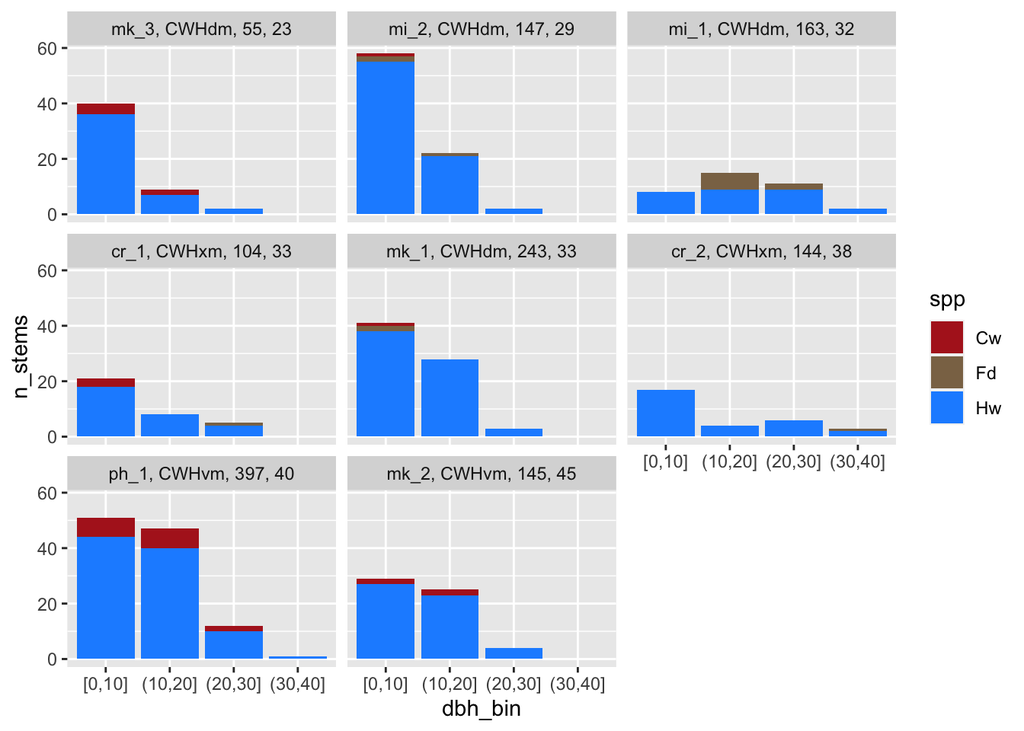

```r
##Regen
reg_struc <- reg_struc %>% filter(ba_m2>0) #Remove rows with 0 because R will plot all dbh intervals (up to 180cm)
ggplot(reg_struc, aes(x=dbh_bin, y=n_stems, fill=spp)) + geom_bar(position="stack", stat="identity") +
  facet_wrap(vars(id_bec_ag_f)) + scale_fill_manual(values = colors_spp)
```

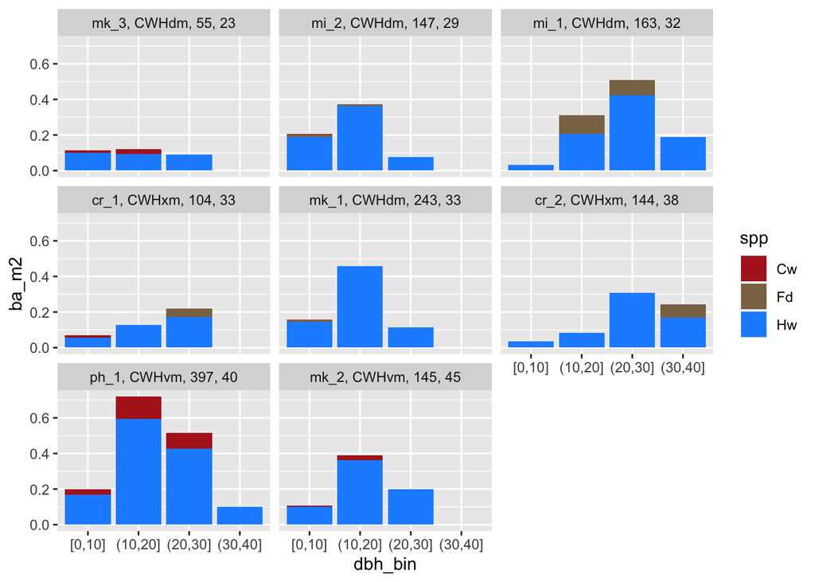

```r
ggplot(reg_struc, aes(x=dbh_bin, y=ba_m2, fill=spp)) + geom_bar(position="stack", stat="identity") +
  facet_wrap(vars(id_bec_ag_f)) + scale_fill_manual(values = colors_spp)
```

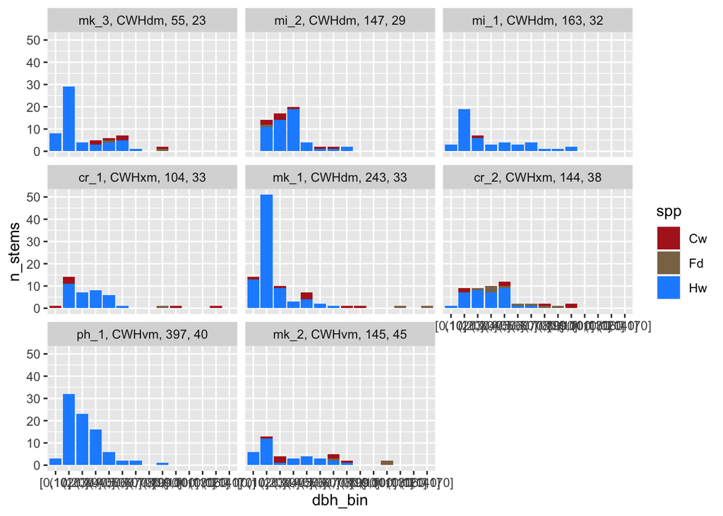

```r
##Mature
mat_struc <- mat_struc %>% filter(ba_m2>0) #Remove rows with 0 because R will plot all dbh intervals (up to 180cm)
ggplot(mat_struc, aes(x=dbh_bin, y=n_stems, fill=spp)) + geom_bar(position="stack", stat="identity") +
  facet_wrap(vars(id_bec_ag_f)) + scale_fill_manual(values = colors_spp)
```

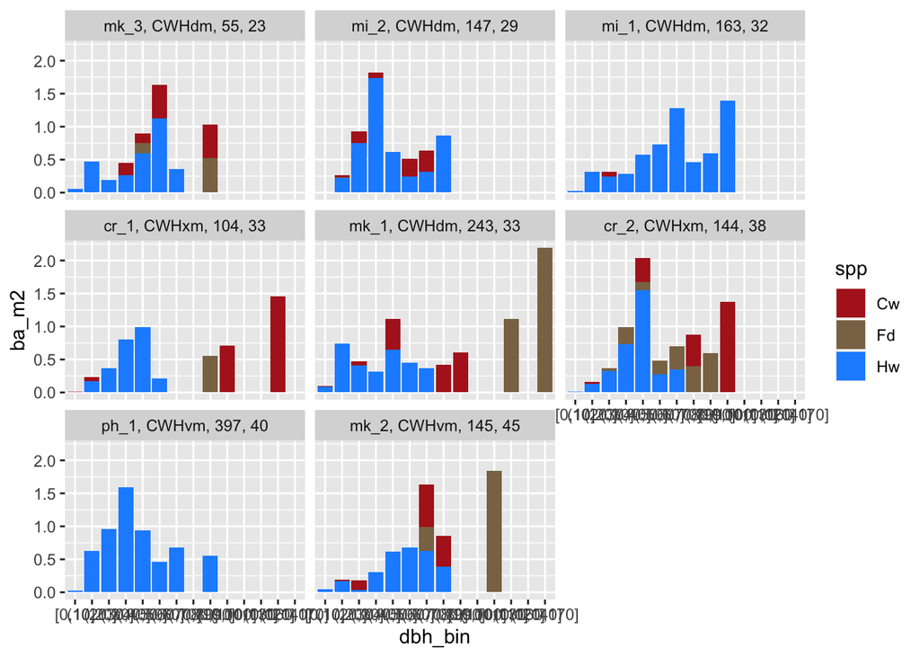

```r
ggplot(mat_struc, aes(x=dbh_bin, y=ba_m2, fill=spp)) + geom_bar(position="stack", stat="identity") +
  facet_wrap(vars(id_bec_ag_f)) + scale_fill_manual(values = colors_spp)
```

Compare the HDM infection in the mature component across the sites by looking at: basal area and stem count distributions parsed out by presence/absence of hdm infection and dmr. Generally trying to assess whether the mature components are similar infection sources. - Some spread in the proportion of the Hw basal area infected (37% at mk_1 to 100% at cr_1) but 7/8 sites>70 and 6 out of 8 > 80%. - Mature components have different basal areas so its important to look at the magnitude (not just proportion) infected - Graph comparing dmr across diameter classes is super useful. Sites with old mature components with severely infected big mature trees have most “inoculum load”.

```r
#Filter to just Hw trees
mat_hw <- mature_comp %>% filter(spp=="Hw") #mature trees

#Start simple. Calculate: basal area of infected trees at each site
mat_inf_ba_m2 <- mat_hw %>% filter(hdm_pa =="Y") %>% group_by(id_bec_ag_f) %>% summarise(mat_inf_ba_m2 = sum(ba_m2))
site <- left_join(site, mat_inf_ba_m2, by="id_bec_ag_f") #join variables back to site data
site <- site %>% mutate(p_mat_hw_ba_inf = mat_inf_ba_m2/mat_hw_ba_m2) #calculate the proportion of Hw basal area that's infected at each site

#Create a summary table.
site %>% select(id_bec_ag_f, mat_hw_ba_m2, mat_inf_ba_m2, p_mat_hw_ba_inf) %>% #summary table sorted by proportion of BA infected
  arrange(p_mat_hw_ba_inf)
```

```
## # A tibble: 8 × 4
##   id_bec_ag_f          mat_hw_ba_m2 mat_inf_ba_m2 p_mat_hw_ba_inf
##   <fct>                       <dbl>         <dbl>           <dbl>
## 1 mk_1, CWHdm, 243, 33         3.02          1.12           0.371
## 2 ph_1, CWHvm, 397, 40         5.83          4.13           0.707
## 3 mk_2, CWHvm, 145, 45         2.86          2.45           0.857
## 4 mi_2, CWHdm, 147, 29         4.76          4.27           0.896
## 5 mk_3, CWHdm, 55, 23          3.06          2.92           0.955
## 6 mi_1, CWHdm, 163, 32         5.91          5.81           0.982
## 7 cr_2, CWHxm, 144, 38         3.37          3.33           0.988
## 8 cr_1, CWHxm, 104, 33         2.55          2.55           1
```

```r
#Now break down basal area and # stems by site, presence/absece of hdm and diameter class
mat_hdmpa <- mat_hw %>% group_by(id_bec_ag_f, hdm_pa, dbh_bin) %>%
  summarise(ba_m2 = sum(ba_m2), n_stems = n()) %>% complete(dbh_bin, fill=list(ba_m2=0, n_stems=0))
```

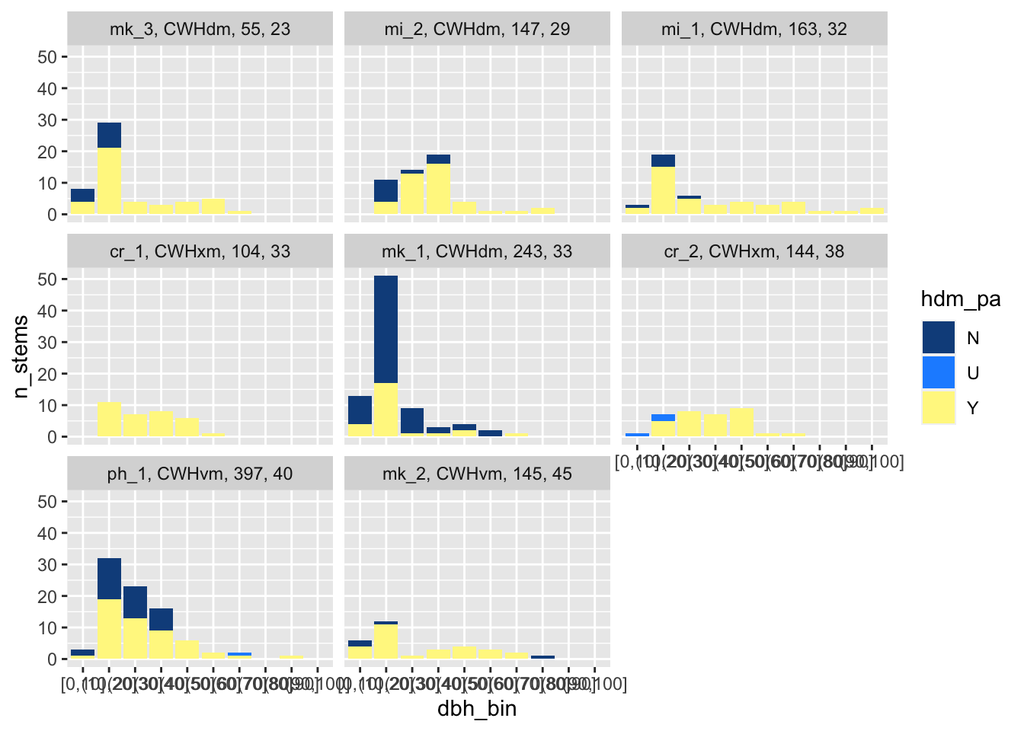

```r
##Graph this across diameter classes
mat_hdmpa <- mat_hdmpa %>% filter(ba_m2>0) #Remove rows with 0 because R will plot all dbh intervals (up to 180cm)
ggplot(mat_hdmpa, aes(x=dbh_bin, y=n_stems, fill=hdm_pa)) + geom_bar(position="stack", stat="identity") +
  facet_wrap(vars(id_bec_ag_f)) + scale_fill_manual(values = colors_dmr_f2)
```

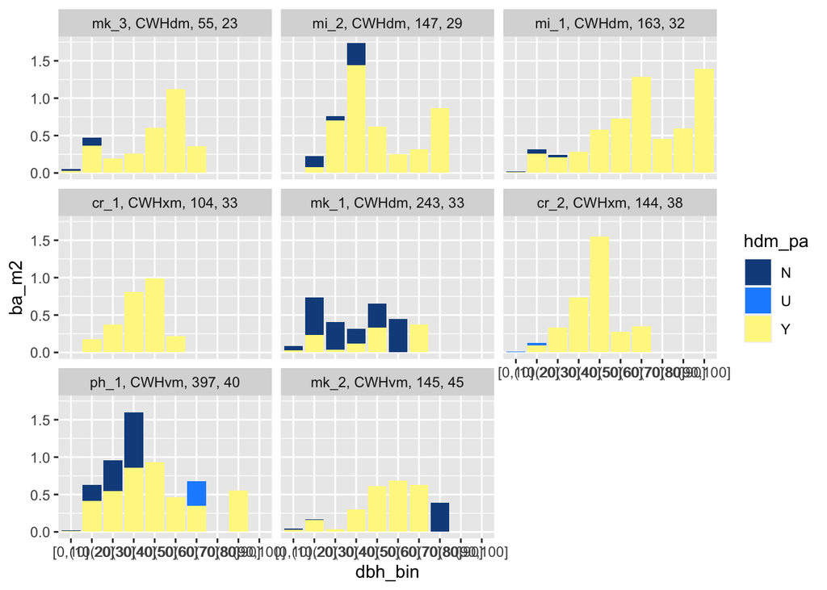

```r
ggplot(mat_hdmpa, aes(x=dbh_bin, y=ba_m2, fill=hdm_pa)) + geom_bar(position="stack", stat="identity") +
  facet_wrap(vars(id_bec_ag_f)) + scale_fill_manual(values = colors_dmr_f2)
```

```r
#Do the same but by DMR
mat_dmr <- mat_hw %>% group_by(id_bec_ag_f, dmr_f2, dbh_bin) %>%
  summarise(ba_m2 = sum(ba_m2), n_stems = n()) %>% complete(dbh_bin, fill=list(ba_m2=0, n_stems=0))
```

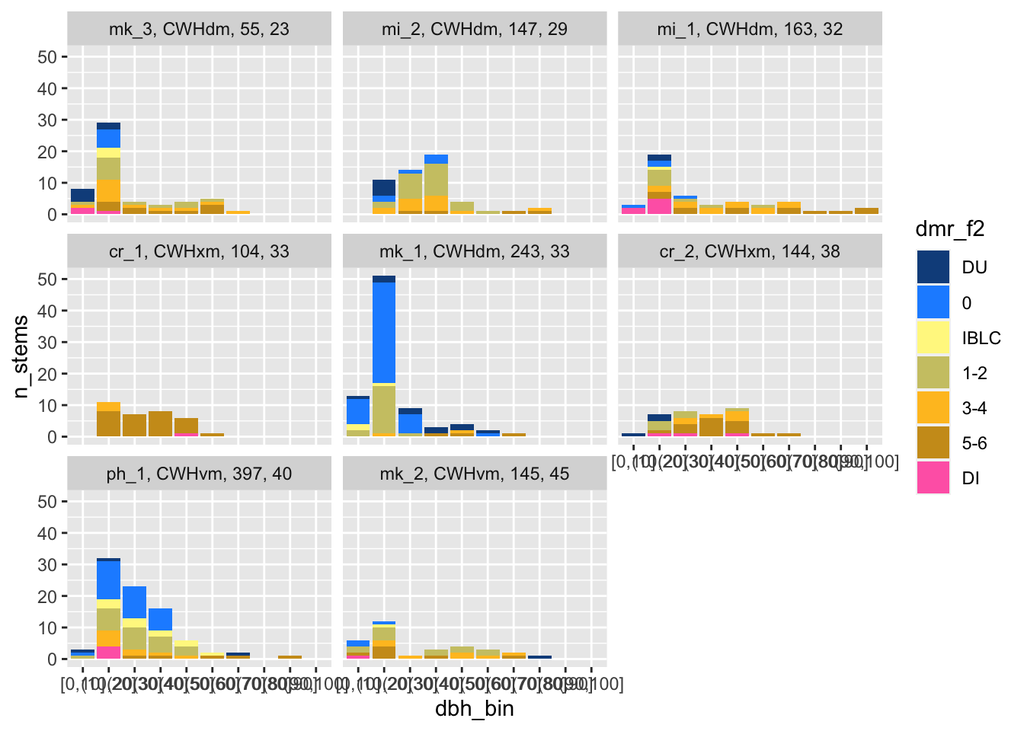

```r
#Graph this across diameter classes
mat_dmr <- mat_dmr %>% filter(ba_m2>0) #Remove rows with 0 because R will plot all dbh intervals (up to 180cm)
ggplot(mat_dmr, aes(x=dbh_bin, y=n_stems, fill=dmr_f2)) + geom_bar(position="stack", stat="identity") +
  facet_wrap(vars(id_bec_ag_f)) + scale_fill_manual(values = colors_dmr_f2)
```

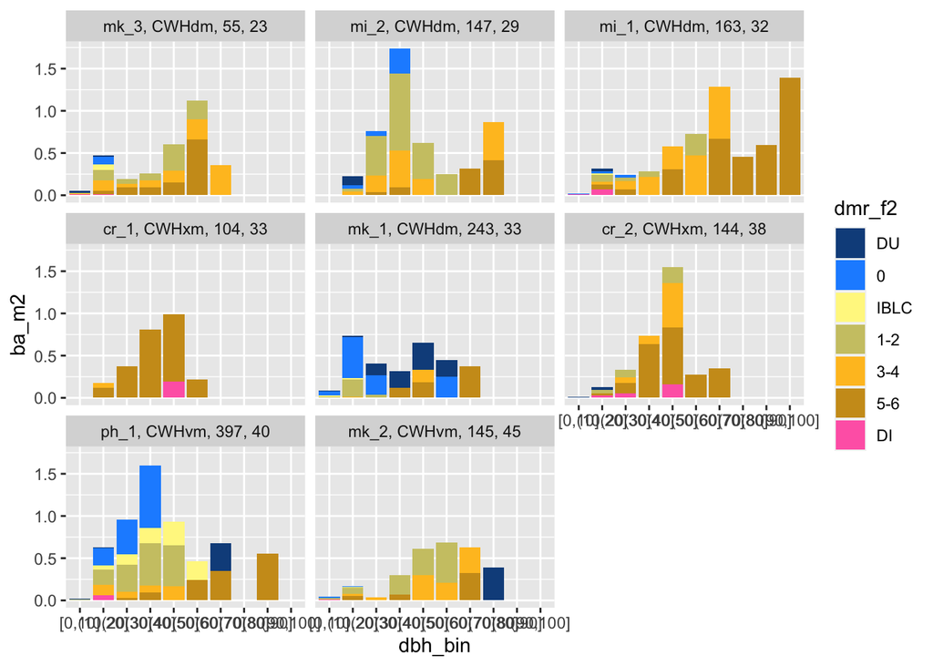

```r
ggplot(mat_dmr, aes(x=dbh_bin, y=ba_m2, fill=dmr_f2)) + geom_bar(position="stack", stat="identity") +
  facet_wrap(vars(id_bec_ag_f)) + scale_fill_manual(values = colors_dmr_f2)
```

Compare infection levels and distribution of infection in the regen compoenent. - Note variable length transects were used and we need to account for this when comparing between sites. Calculating the proportion of the total basal area that is infected at a site isn’t useful. i.e. 50% infection at site 1 vs 40% infection at site 2 isn’t a meaningful comparison if site 1 and site 2 have different length transects. Deal with this in two ways: compare total magnitude (e.g. basal area infected) –> sites with longer transects are places where more spread has occured amd will likely have higher total magnitudes OR compare discrete intervals (e.g. basal area infected within 15m) - There portion of Hw basal within 15m from infected wtih hdm ranges from ~0 - 72% but this spread is mostly caused by an outlier (ph_1) and the young site (mk_3). Between the other six sites, the range is 60-72%. - Notable from plots of ba ~ dist_y, coloured by dmr is that most infection is light. - FOLLOW UP: some of trees at mi_1 that are severely infected are trees we thought might have been residuals. Check these and their cores?

```r
#Filter full dataset (not trees_comp which filters transects to <15m)
reg_hw <- trees %>% filter(tree_type == "regen" & spp=="Hw") #Hemlock regen trees

#Start simple again, just calculate basal area infected at each site
reg_inf_ba_m2 <- reg_hw %>% filter(hdm_pa =="Y") %>% group_by(id_bec_ag_f) %>% summarise(reg_inf_ba_m2 = sum(ba_m2))
reg_15_inf_ba_m2 <- regen_15 %>% filter(hdm_pa =="Y") %>% group_by(id_bec_ag_f) %>% summarise(reg_15_inf_ba_m2 = sum(ba_m2))
site <- left_join(site, reg_inf_ba_m2, by="id_bec_ag_f") #join variables back to site data
site <- left_join(site, reg_15_inf_ba_m2, by="id_bec_ag_f")
site <- site %>% mutate(p_reg_15_ba_inf = reg_15_inf_ba_m2/reg_tot_ba_m2)

#Create a summary table.
site %>% select(id_bec_ag_f, reg_hw_ba_m2, reg_inf_ba_m2, reg_15_inf_ba_m2, p_reg_15_ba_inf) %>%
  arrange(reg_15_inf_ba_m2) #summary table sorted by portion of BA infected within 15m of edge
```

```
## # A tibble: 8 × 5
##   id_bec_ag_f        reg_hw_ba_m2 reg_inf_ba_m2 reg_15_inf_ba_m2 p_reg_15_ba_inf
##   <fct>                     <dbl>         <dbl>            <dbl>           <dbl>
## 1 ph_1, CWHvm, 397,…        1.29        0.00650          0.00650         0.00425
## 2 mk_3, CWHdm, 55, …        0.283       0.0857           0.0857          0.216
## 3 cr_1, CWHxm, 104,…        0.355       0.813            0.322           0.602
## 4 mk_1, CWHdm, 243,…        0.718       0.592            0.446           0.592
## 5 mk_2, CWHvm, 145,…        0.663       0.796            0.458           0.659
## 6 mi_2, CWHdm, 147,…        0.629       0.491            0.471           0.714
## 7 cr_2, CWHxm, 144,…        0.601       0.638            0.487           0.719
## 8 mi_1, CWHdm, 163,…        0.846       0.866            0.780           0.717
```

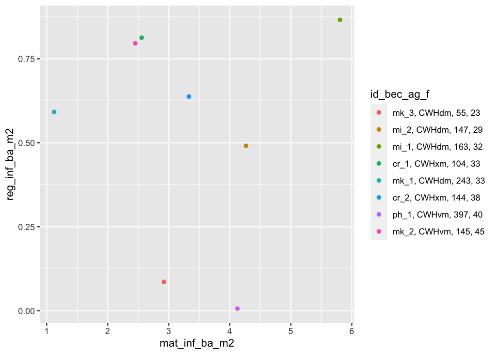

```r
#Create a plot relating basal area infected in mature component to basal area infected in the regen
ggplot(site, aes(x=mat_inf_ba_m2, y=reg_inf_ba_m2, color=id_bec_ag_f)) +
  geom_point()
```

```r
## Can't really see anything, too few datapoints, but my sense is that inocukum pressure is going to be the key variable

#Do some plotting looking at HDM infection vs distance from the edge
##Break up dist_y_h into intervals. Need these to make barcharts
summary(reg_hw$dist_y_h)
```

```
##     Min.  1st Qu.   Median     Mean  3rd Qu.     Max.
##  0.07749  5.00113 10.70312 11.66670 16.08588 33.20974
```

```r
reg_hw <- reg_hw %>% mutate(dist_y_h_bin = cut(dist_y_h, breaks = c(0, 5, 10, 15, 20, 25, 30, 35), include.lowest = TRUE))
levels(reg_hw$dist_y_h_bin)
```

```
## [1] "[0,5]"   "(5,10]"  "(10,15]" "(15,20]" "(20,25]" "(25,30]" "(30,35]"
```

```r
##Summarize basal area and the # stems by site, presence/absence of hdm and distance from the edge (in the 5m intervals created above)
reg_hdmpa <- reg_hw %>% group_by(id_bec_ag_f, hdm_pa, crown_class, dist_y_h_bin) %>%
  summarise(ba_m2 = sum(ba_m2), n_stems = n()) %>%
  complete(dist_y_h_bin, fill=list(ba_m2=0, n_stems=0))
```

```
## can override using the `.groups` argument.
```

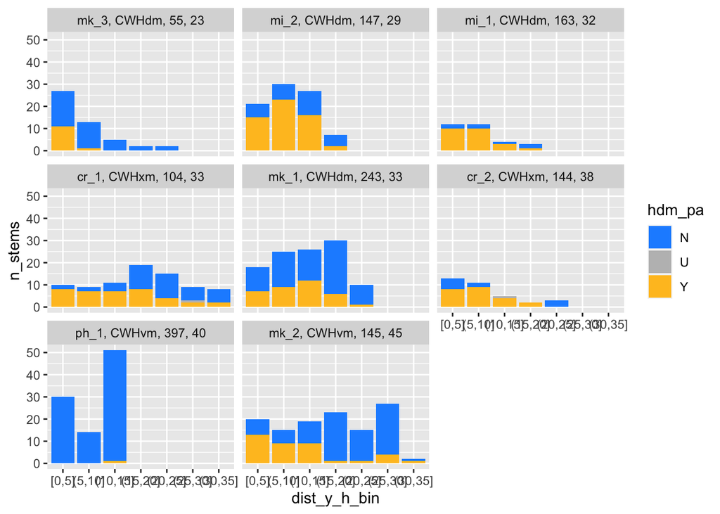

```r
##Plot nstems and basal area vs. distance from the edge, coloured by presence/absence of hdm infection
ggplot(reg_hdmpa, aes(x=dist_y_h_bin, y=n_stems, fill=hdm_pa)) + geom_bar(position="stack", stat="identity") +
  facet_wrap(vars(id_bec_ag_f)) + scale_fill_manual(values = colors_hdm_pa)
```

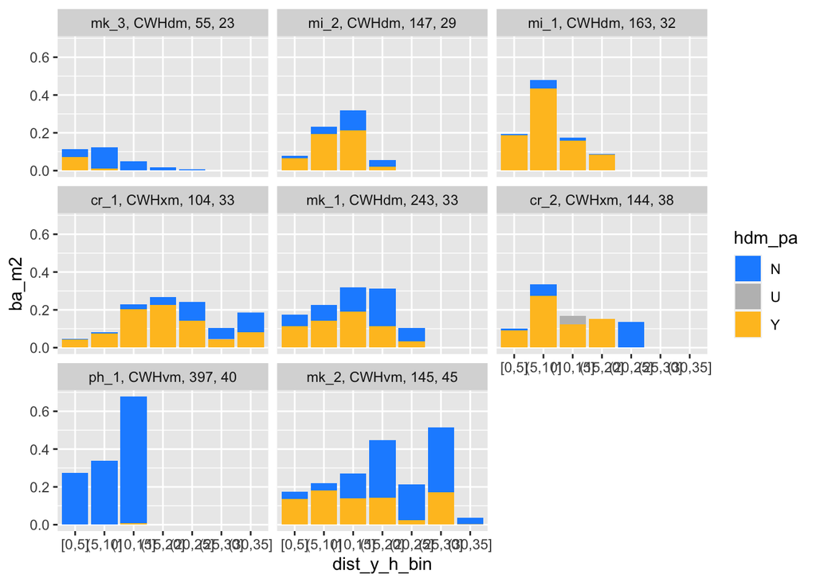

```r
ggplot(reg_hdmpa, aes(x=dist_y_h_bin, y=ba_m2, fill=hdm_pa)) + geom_bar(position="stack", stat="identity") +
  facet_wrap(vars(id_bec_ag_f)) + scale_fill_manual(values = colors_hdm_pa)
```

```r
##Do the same but with DMR.
reg_dmr <- reg_hw %>% group_by(id_bec_ag_f, dmr_f2, crown_class, dist_y_h_bin) %>%
  summarise(ba_m2 = sum(ba_m2), n_stems = n()) %>%
  complete(dist_y_h_bin, fill=list(ba_m2=0, n_stems=0))
```

```
## can override using the `.groups` argument.
```

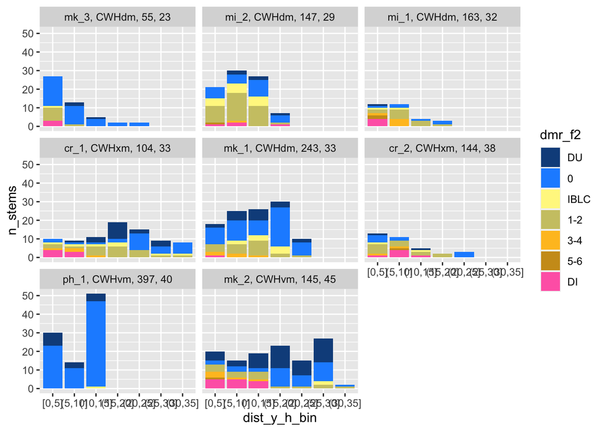

```r
##Plot nstems and basal area across distance from the edge, coloured by presence/absence of hdm infection
ggplot(reg_dmr, aes(x=dist_y_h_bin, y=n_stems, fill=dmr_f2)) + geom_bar(position="stack", stat="identity") +
  facet_wrap(vars(id_bec_ag_f)) + scale_fill_manual(values = colors_dmr_f2)
```

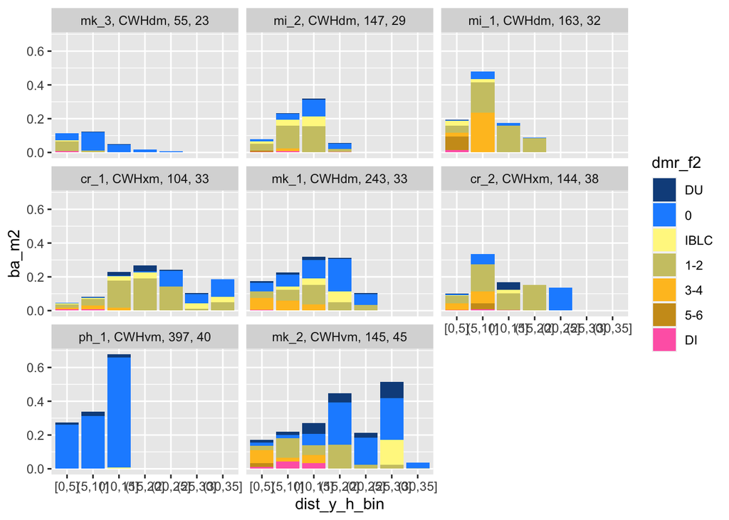

```r
ggplot(reg_dmr, aes(x=dist_y_h_bin, y=ba_m2, fill=dmr_f2)) + geom_bar(position="stack", stat="identity") +
  facet_wrap(vars(id_bec_ag_f)) + scale_fill_manual(values = colors_dmr_f2)
```

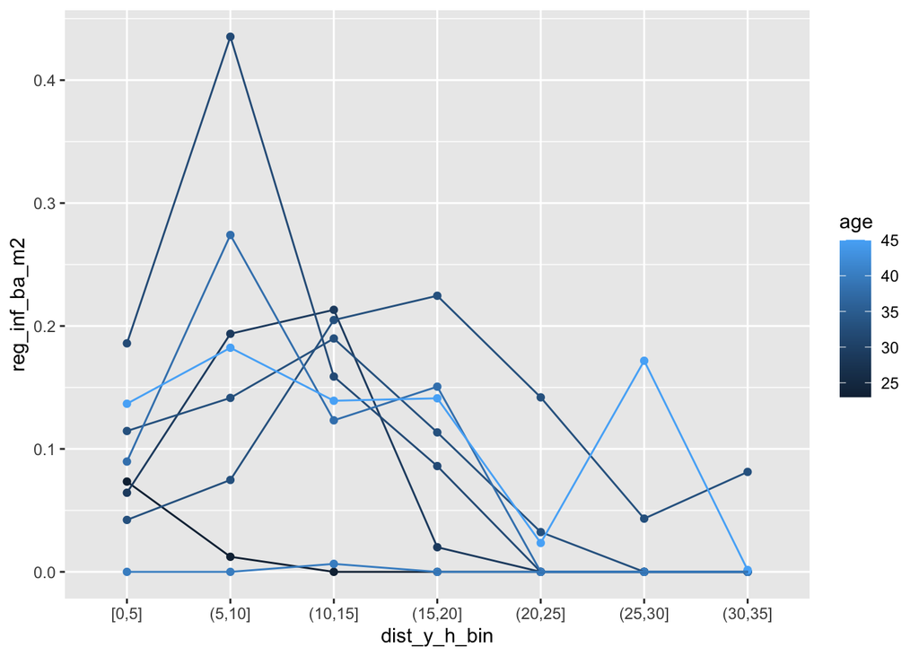

```r
#Do some plotting to see if you can pick up patterns that relate the basal area of infected regen to site level variables
##Relating basal area infected by distance from the edge to site age
reg_inf_ag <- reg_hw %>% filter(hdm_pa=="Y") %>%
  group_by(id_bec_ag_f, age, dist_y_h_bin) %>% summarise(reg_inf_ba_m2 = sum(ba_m2)) %>%
  complete(dist_y_h_bin, fill=list(reg_inf_ba_m2=0))
ggplot(reg_inf_ag, aes(x=dist_y_h_bin, y=reg_inf_ba_m2, color = age, group = id_bec_ag_f)) +
  geom_point() + geom_line()
```

```r
##Relating basal area infected by distance from the edge to basal area infected in mature component
reg_inf_matinf <- reg_hw %>% filter(hdm_pa=="Y") %>%
  group_by(id_bec_ag_f, dist_y_h_bin) %>% summarise(reg_inf_ba_m2 = sum(ba_m2)) %>%
  complete(dist_y_h_bin, fill=list(reg_inf_ba_m2=0))
reg_inf_matinf <- left_join(reg_inf_matinf, select(site, id_bec_ag_f, mat_inf_ba_m2))
```

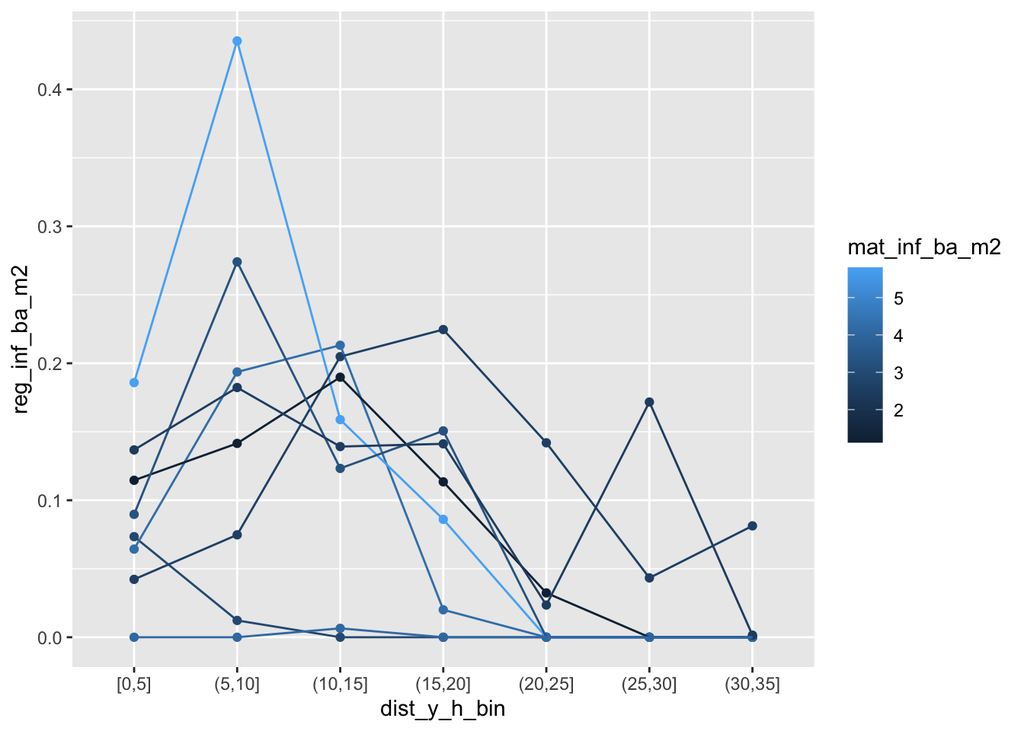

```r
ggplot(reg_inf_matinf, aes(x=dist_y_h_bin, y=reg_inf_ba_m2, color = mat_inf_ba_m2, group = id_bec_ag_f)) +
  geom_point() + geom_line()
```